# Training versus Testing

As we seen before, we can estimate the out-of-sample error $E_{out}$ from the in-sample error $E_{in}$. While the estimate can be useful as a guideline for the training process, it is next to useless if the goal is to get an accurate forecast of Eout . If you are developing a system for a customer, you need a more accurate estimate so that your customer knows how well the system is expected to perform.

## The Test Set

An alternative approach is to estimate $E_{out}$ by using a test set, a data set that was not involved in the training process. The final hypothesis $g$ is evaluated on the test set, and the result is taken as an estimate of $E_{out}$·

Another aspect that distinguishes the test set from the training set is that the test set is not biased. Both sets are finite samples that are bound to have some variance due to sample size, but the test set doesn't have an optimistic or pessimistic bias in its estimate of $E_{out}$. The training set has an optimistic bias, since it was used to choose a hypothesis that looked good on it.

*What is the price to be paid for having a test set?*

[figure not shown]

## Other Target Types

Previously, we defined $E_{in}$ and $E_{out}$ as binary-based functions

$$ E_{in}(h) = \frac{1}{N} \sum_{n=1}^N [\![ h(\boldsymbol{x}_n) \neq f(\boldsymbol{x}_n) ]\!] $$$$ E_{out}(h) = P[ h(\boldsymbol{x}) \neq f(\boldsymbol{x}) ] $$

In order to deal with real-valued functions, we need to adapt these definitions.

If $f$ and $h$ are real-valued, a more appropriate error measure would gauge how far $f(\boldsymbol{x})$ and $h(\boldsymbol{x})$ are from each other, rather than just whether their values are exactly the same.

An error measure that is commonly used in this case is the squared error $e(h(\boldsymbol{x}), f(\boldsymbol{x})) = (h(\boldsymbol{x}) - f(\boldsymbol{x}))^2$. We can define in-sample and out-of-sample versions of this error measure.

$$ E_{in}(h) = \frac{1}{N} \sum_{n=1}^N (h(\boldsymbol{x}_n) - f(\boldsymbol{x}_n))^2 $$$$ E_{out}(h) = \mathbb{E}[ (h(\boldsymbol{x}) - f(\boldsymbol{x}))^2 ] $$

**Excersise**

For binary target functions, show that $P[h(\boldsymbol{x}) \neq f(\boldsymbol{x})]$ can be written as an expected value of a mean squared error measure in the following cases.

- The convention used for the binary function is 0 or 1.
- The convention used for the binary function is $\pm 1$.

*Hint: The difference between both is just a scale*

## The Bias-Variance Decomposition

The bias-variance decomposition of out-of-sample error is based on squared error measures. The out-of-sample error is

$$ E_{out}(g^{(\mathcal{D})}) = \mathbb{E}_{\boldsymbol{x}}[ (g^{(\mathcal{D})}(\boldsymbol{x}) - f(\boldsymbol{x}))^2 ] $$

We can rid the equation of the dependence on a particular data set by taking the expectation with respect to all data sets. We then get the expected out-of-sample error for our learning model, independent of any particular realization of the data set.

$$ \mathbb{E}_{\mathcal{D}} \left[ E_{out}(g^{(\mathcal{D})}) \right] = \mathbb{E}_{\mathcal{D}} \left[ \mathbb{E}_{\boldsymbol{x}}[ (g^{(\mathcal{D})}(\boldsymbol{x}) - f(\boldsymbol{x}))^2 ] \right] \\ = \mathbb{E}_{\boldsymbol{x}} \left[ \mathbb{E}_{\mathcal{D}}[ (g^{(\mathcal{D})}(\boldsymbol{x}) - f(\boldsymbol{x}))^2 ] \right] \\ = \mathbb{E}_{\boldsymbol{x}} \left[ \mathbb{E}_{\mathcal{D}}[ g^{(\mathcal{D})}(\boldsymbol{x})^2 ] - 2 \mathbb{E}_{\mathcal{D}}[ g^{(\mathcal{D})}(\boldsymbol{x})] f(\boldsymbol{x}) + f(\boldsymbol{x})^2 \right] $$

The term $\mathbb{E}_{\mathcal{D}}[ g^{(\mathcal{D})}(\boldsymbol{x})]$ gives an "average function", which we denote by $\bar{g}(\boldsymbol{x})$. How do you interpret $\bar{g}(\boldsymbol{x})$ in an operational way?

*Note: The function $\bar{g}$ is a little counterintuitive; for one thing, $\bar{g}$ need not be in the model's hypothesis set, even though it is the average of functions that are.*

**Excersise**

Show that if $\mathcal{H}$ is closed under linear combination (any linear combination of hypotheses in $\mathcal{H}$ is a lso a hypothesis in $\mathcal{H}$), then $\bar{g} \in \mathcal{H}$.

We can now rewrite the expected out-of-sample error in terms of $\bar{g}$

$$ \mathbb{E}_{\mathcal{D}} \left[ E_{out}(g^{(\mathcal{D})}) \right] \\ = \mathbb{E}_{\boldsymbol{x}} \left[ \mathbb{E}_{\mathcal{D}}[ g^{(\mathcal{D})}(\boldsymbol{x})^2 ] - 2 \bar{g}(\boldsymbol{x}) f(\boldsymbol{x}) + f(\boldsymbol{x})^2 \right] \\ = \mathbb{E}_{\boldsymbol{x}} \left[ \mathbb{E}_{\mathcal{D}}[ g^{(\mathcal{D})}(\boldsymbol{x})^2 ] - \bar{g}(\boldsymbol{x})^2 + \bar{g}(\boldsymbol{x})^2 - 2 \bar{g}(\boldsymbol{x}) f(\boldsymbol{x}) + f(\boldsymbol{x})^2 \right] \\ = \mathbb{E}_{\boldsymbol{x}} \left[ \mathbb{E}_{\mathcal{D}}[ g^{(\mathcal{D})}(\boldsymbol{x})^2 - \bar{g}(\boldsymbol{x})^2] + (\bar{g}(\boldsymbol{x}) - f(\boldsymbol{x}))^2 \right] $$

where

$$ bias(\boldsymbol{x}) = (\bar{g}(\boldsymbol{x}) - f(\boldsymbol{x}))^2 \\ var(\boldsymbol{x}) = \mathbb{E}_{\mathcal{D}}[ g^{(\mathcal{D})}(\boldsymbol{x})^2 - \bar{g}(\boldsymbol{x})^2] $$

How do you interpret these terms?

We thus arrive at the bias-variance decomposition of out-of-sample error,

$$ \mathbb{E}_{\mathcal{D}} \left[ E_{out}(g^{(\mathcal{D})}) \right] = \mathbb{E}_{\boldsymbol{x}} \left[ bias(\boldsymbol{x}) + var(\boldsymbol{x}) \right] = bias + var $$

### Example

Consider a target function $f(x)=sin(\pi x)$ and a data set of size $N=2$. We sample $x$ uniformly in $[-1,1)$ to generate a data set $(x_1 , y_1), (x_2, y_2)$ and fit the data using one of two models:

- $\mathcal{H}_0$: Set of all lines of the form $h(x)=b$;
- $\mathcal{H}_1$: Set of all lines of the form $h(x)=ax+b$.

For $\mathcal{H}_0$, we choose the constant hypothesis that best fits the data (the horizontal line at the midpoint, $b=\frac{y_1 + y_2}{2}$

For $\mathcal{H}_1$ , we choose the line that passes through the two data points $(x_1 , y_1)$ and $(x_2, y_2)$.

Repeating this process with many data sets, we can estimate the bias and the variance.

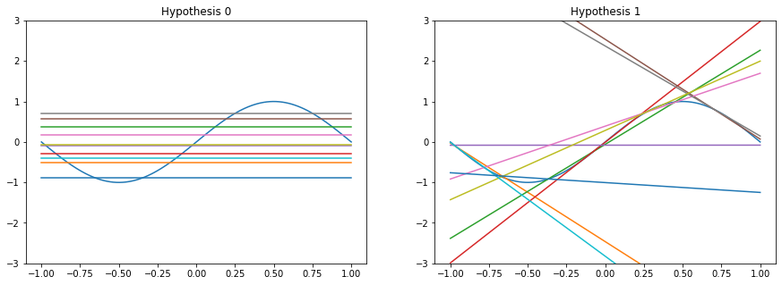

```python
figure
```

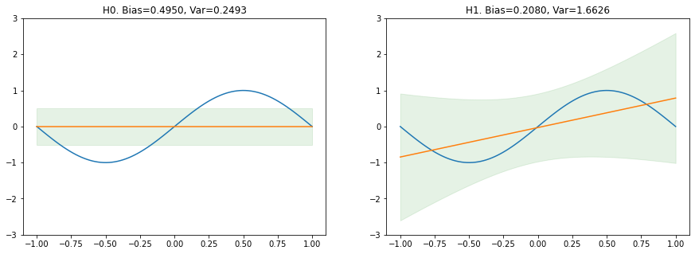

```python
figure
```

Although the bias-variance analysis is based on squared-error measure, the learning algorithm itself does not have to be based on minimizing the squared error. It can use any criterion to produce $g^{(\mathcal{D})}$ based on $\mathcal{D}$. However, once the algorithm produces $g^{(\mathcal{D})}$, we measure its bias and variance using squared error.

Unfortunately, the bias and variance cannot be computed in practice, since they depend on the target function and the input probability distribution (both unknown). Thus, the bias-variance decomposition is a conceptual tool which is helpful when it comes to developing a model. There are two typical goals when we consider bias and variance. The first is to try to lower the variance without significantly increasing the bias, and the second is to lower the bias without significantly increasing the variance.

## The Learning Curve

The learning curves summarize the behavior of the in-sample and out-of-sample errors as we vary the size of the training set.

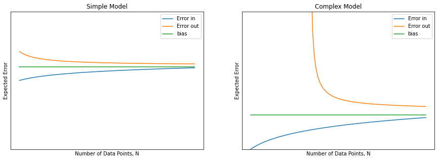

```python
figure
```